# Effects of Borrower Categories on the Borrower APR

## by Job Wachira

## Investigation Overview

The goal of this investigation is to determine how different categorical variables affect the borrower APR. For this instance, our focus will be on how the custom prosper score, income range and home ownership interact with the borrower APR.

My key insignt will be that the Prosper Score, income range and homeownership all have an effect on the borrower APR one can get. The higher your prosper score, the lower your APR. The higher your income range the lower the APR you get and home owners seem to on average enjoy a lower APR across listing categories.

## Dataset Overview

This data set contains 113,937 loans with 81 variables on each loan, including loan amount, borrower rate (or interest rate), current loan status, borrower income, and many others.

## Borrower APR by Prosper Score.

The *Prosper Score* is a custom risk score built using historical prosper data. It goes from 1 to 10 with 1 being the highest risk level and 10 the lowest.

We investigate it's relationship with the borrower APR by plotting a box plot so that we can see the change in the median borrower APR for the different prosper scores.

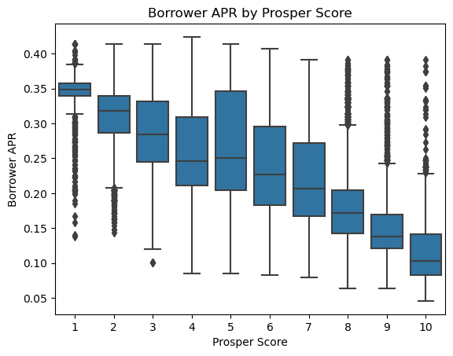

## Borrower APR by Income Range and Term

Here we show the borrower API for different terms faceted by income range.

By faceting using income range, we can see how the median borrower APR drops as we go up the income ranges. It's important to note, however, that loans with a 36 month term seem to have a higher APR, probably because they constitue the bulk of loans and have more variability. However, even for that term, there is a decrease in the borrower APR as you move to higher income ranges.

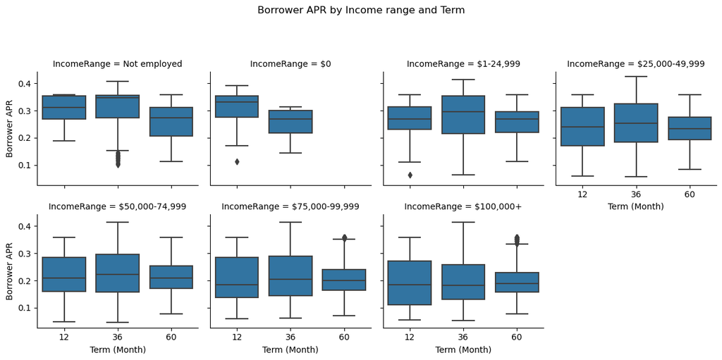

## Borrower APR by Listing Category and Home Ownership

Here we are going to measure the mean borrower APR for different listing categories, split by homwownership.

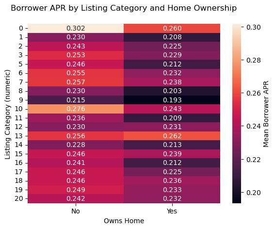